- [View **PDF**](https://www.sciencedirect.com/science/article/pii/S2666154322000187/pdfft?md5=f871ed5d74444c174e5e79cb63d4e34e&pid=1-s2.0-S2666154322000187-main.pdf)

## [Journal of Agriculture and Food Research](https://www.sciencedirect.com/journal/journal-of-agriculture-and-food-research)

[Volume 8](https://www.sciencedirect.com/journal/journal-of-agriculture-and-food-research/vol/8/suppl/C), June 2022, 100285

# Valorizing staple crop residues through mushroom production to improve food security in eastern Democratic Republic of Congo

https://doi.org/10.1016/j.jafr.2022.100285[Get rights and content](https://s100.copyright.com/AppDispatchServlet?publisherName=ELS&contentID=S2666154322000187&orderBeanReset=true)

Under a Creative Commons [license](http://creativecommons.org/licenses/by-nc-nd/4.0/)

open access

## Highlights

**•**

Food insecurity and poverty in rural South-Kivu are mainly linked with low crop productivity.

**•**

Options for valorizing crop residues could be instrumental for food security and poverty alleviation.

**•**

Mushroom production is a cost-effective and profitable option in valorizing staple crops residues.

**•**

Scaling mushroom production would economically empower rural households and reduce pressure on natural resources in South-Kivu.

## Abstract

Food security is challenged by low agricultural productivity in eastern Democratic Republic of Congo (DRC). This study aimed at contributing to food security of rural households in South-Kivu by valorizing residues of four staple crops, including cassava, maize, banana, and common bean. The study was conducted in two steps: (1) monitoring of farmers' fields throughout the cropping season to record weight of [crop residues](https://www.sciencedirect.com/topics/agricultural-and-biological-sciences/crop-residue) and yields, and (2) assessment of the potential of staple crop residues for mushroom (*[Pleurotus ostreatus](https://www.sciencedirect.com/topics/agricultural-and-biological-sciences/pleurotus-ostreatus)*) production. Results showed that the four major staple crops had low yields and low biomass productivity in the study area. Residues of these staple crops were mainly used by farmers as fodder, compost, incinerated, or left on the farm for nutrient recycling. In addition to target plant parts (tubers or grains), cassava and common bean leaves were harvested for household consumption (as vegetables) or traded at local markets for income generation. Substrates based on maize residues, combined with cow manure as additive, gave the highest yield of *P. ostreatus* (2.4 kg kg<sup>−1</sup>) compared to residues of other three staple crops. In contrast, substrates from banana leaves had consistently lowest yields, regardless of used additives (1.1 and 1.2 kg kg<sup>−1</sup> with soybean flour and cow manure, respectively). This study showed that valorizing residues of staple crops could help improve households’ food security and income in rural areas of eastern DRC. This practice should, therefore, be encouraged and scaled across the country and other parts of the world facing food shortages and poverty.

## Graphical abstract

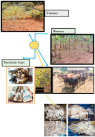

## Keywords

Crop residues

Valorization

Oyster mushroom

Food security

Participatory research

South-Kivu

## 1. Introduction

Alleviating hunger and poverty are major priorities of several national and international organizations worldwide [1,2]. Despite multiple efforts, the Sub-Saharan African (SSA) countries are still lagging behind in these global races due to several biophysical, ecological, political, social, and demographic challenges [3,4]. Like in most SSA countries, ∼80% of the populations in Democratic Republic of Congo (DRC) live in rural areas and solely depend on family farming for food and livelihood [5,6]. Of the major cultivated staples, root and [tuber crops](https://www.sciencedirect.com/topics/agricultural-and-biological-sciences/tuber-crops), cereals, banana, and legumes are the most predominant [7,8]. These crops are grown in most Congolese provinces and represent almost 70% of the total food supply [9]. Besides, there are few industrial crops such as coffee, sugar cane, tea, cocoa, and cotton that are mostly practiced in the eastern provinces [7]. In the eastern part of the country, and particularly in the South-Kivu province, these crops contribute strongly to food availability, job creation, and income sources for smallholder households [10].

Most of these staple crops are multipurpose and provide a range of by-products. For instance, both cassava leaves and tubers are consumed and help to improve food security among resource-poor households [7,11]. Cassava leaves are often used as a vegetable for their richness in protein, and fodder for livestock while the stem is a source of cuttings (planting materials) and firewood. On the other hand, cassava tubers are either consumed boiled, raw, or processed into flour to make bread, fufu and other local recipes [7,12]. Banana fruits are consumed fresh, fried, cooked, or processed into flour. Banana pulp is dried and processed into flour mainly for children feed while peels serve as fodder. Beer banana varieties are locally processed into traditional juice (known as "Mutobe" in Swahili or "Murhobo" in Mashi) or wine (known locally as "Kasiksi"), depending on the fermentation procedure. The local banana wine plays an important socio-cultural role in various traditional ceremonies such as wedding and burial. Banana provides also raw material for housing in less privileged areas of DRC. It is noteworthy that [provitamin A](https://www.sciencedirect.com/topics/agricultural-and-biological-sciences/carotene) banana are used to combat hidden hunger among resource-poor populations of North- and South-Kivu [13].

The eastern DRC is characterized by the highest per capita consumption for common bean worldwide (200–300 g per person per day) [14,15]. Common bean grains and leaves are consumed to supply [dietary proteins](https://www.sciencedirect.com/topics/agricultural-and-biological-sciences/dietary-protein), complex carbohydrates, micronutrients, vitamins and amino acids, and thus, they help combating hidden hunger in the region [15]. Part of the common bean residues is used as animal feed while preliminary studies for bean processing, to reach export market expectations, has been initiated [16]. Another major crop in eastern DRC is the maize, the first [cereal crop](https://www.sciencedirect.com/topics/agricultural-and-biological-sciences/cereal-crop) practiced in the country [17]; it is consumed raw, boiled, or as flour to make different recipes while its residues serve as feed for animal, firewood or stakes of other staple crops such as climbing common beans.

Unfortunately, these staple crops are currently challenged by biotic and abiotic constraints, including declined soil fertility as a result of soil overexploitation [18,19], climate change, diseases, [insect pests](https://www.sciencedirect.com/topics/agricultural-and-biological-sciences/insect-pests), and a faulty seed delivery system [20]. These production-limiting factors make the population of this region prone to food insecurity and poverty [7,21,22]. In such a context, searching for alternative solutions that can allow diversifying and increasing food production is needed to ensure food security and poverty alleviation and to reduce the pressure on natural resources like forests. One of the most promising solutions is the edible mushroom production using staple [crop residues](https://www.sciencedirect.com/topics/agricultural-and-biological-sciences/crop-residue) [23,24].

As described above, staple crops in South-Kivu are multipurpose and thus produced in huge amount by local farmers to cover household needs and the market demand. Although residues of these crops are often multipurpose, a largest part of them is left on ground or burned after harvest. Low valorization of these residues is mostly due lack of proper knowledge on how to make better use of them to strengthen the farmers’ food and income security [24].

In 2013, the Université Evangélique en Afrique (UEA), Bukavu, DRC, created a research unit on mushroom production and promotion as part of the effort to combat chronic malnutrition and poverty in eastern DRC. This initiative sought to achieve its objectives by valorizing local resources, including residues of staple crops. Indeed, mushroom cultivation provides a range of opportunities for strengthening the food and financial security of local populations in the context of South-Kivu: mushroom has a short growth cycle (2–3 weeks), it is not seasonal, and therefore, not sensitive to climatic hazards. Besides, mushroom cultivation is not land- and labor-intensive, since 1–10 m<sup>2</sup> of land is sufficient. Mushroom has a high potential yield (2000 kg per acre, by far higher than that of all known staple crops in DRC). Furthermore, mushroom production does not require large investments for the start-up (and, therefore, favorable to women and youths who have limited financial and land resources) [25,26]. The soilless production of mushroom (where the cultivation is done under shed and on a shelf) reduces dependency on weather factors such as rainfall and temperature which are, however, critical for conventional crops (maize, beans, cassava, etc.). The mushroom is, therefore, a climate resilient crop. It is noteworthy that residues can still be used as organic matter, animal or fish feed after use for mushroom production in the inter-season [24].

Research initiatives to optimize mushroom production from UEA Mushroom Research Unit were successful and thus attracted supports from national and international organizations to extent activities to local communities, including women organizations and farmers’ cooperatives in rural areas. Most of those farmer-support structures perceived the introduction of mushroom production as a means to strengthen the resilience of local populations to the adverse effects of climate change and the consolidation of forest resources.

Based on past experiences, it was realized that durability of the mushroom production in the eastern DRC would depend on increasing productivity of locally-available resources rather than importing those used elsewhere [12,21,26,27]. Successful use of staple crops’ residues, such as naked maize cobs, banana leaves, common bean residues, *[Pennisetum purpureum](https://www.sciencedirect.com/topics/agricultural-and-biological-sciences/pennisetum-purpureum)**,* etc. was reported in research stations of South-Kivu [21,26], and in the neighboring country Burundi [24,25].

This work reports on the earliest attempts to introduce mushroom production in rural South-Kivu as a path towards food security among smallholder households. Specifically, it sought to: (i) quantify residues of staple crops like cassava, maize, banana, and common bean that can be valorized in oyster mushroom production; (ii) investigate major destinations of crop residues after harvests; (iii) evaluate mushroom yield potential of substrates made from residues of these staple crops; and (iv) assess supplementation options that could optimize productivity in mushroom of crop residues using local additives. The particularity of this research is that it involved directly local farmer cooperatives in the study design, experiment setting, and data collection, under the supervision of the UEA Mushroom Research Unit. We assumed that farmers’ active participation in testing new agricultural technologies would increase uptake and sustainability, even after the research period has ended.

## 2. Materials and methods

### 2.1. Study area

The study was conducted in Mushinga area, Walungu territory, South-Kivu province, eastern DRC. Mushinga is part of the Ngweshe chiefdom and is located at 2°44′S, 28°40′E and at elevations of ∼1600 m above sea level (masl) (Fig. 1). Like other highland regions of the Bushi, Mushinga is characterized by a humid tropical climate tempered with elevation [7,8,28,29]. It experiences a mean annual temperature of ∼21 °C and a bimodal rainfall regime (1200–1800 mm yearly). The dry season lasts three months (June to August) while the rainy season covers nine months (September to May). Soil types are mainly [Ferralsols](https://www.sciencedirect.com/topics/agricultural-and-biological-sciences/ferralsol) and [Nitisols](https://www.sciencedirect.com/topics/agricultural-and-biological-sciences/nitisols), with an acidic pH (4–6), low organic matter (OM) content and low cation exchange capacity (CEC). The vegetation is dominated by a mosaic of fields and fallows, forests, and grasslands.

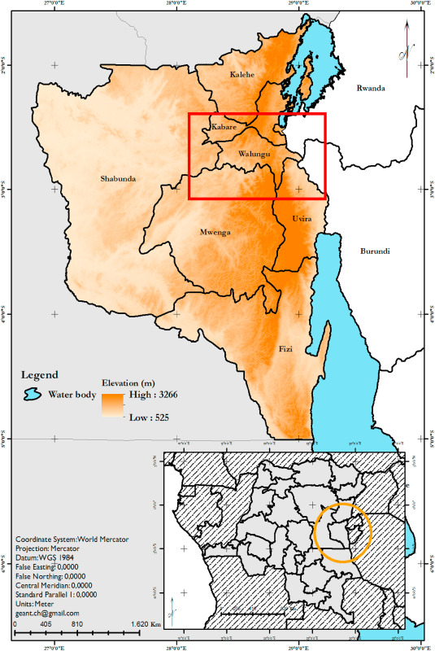

1. [Download : Download high-res image (2MB)](https://ars.els-cdn.com/content/image/1-s2.0-S2666154322000187-gr1_lrg.jpg)
2. [Download : Download full-size image](https://ars.els-cdn.com/content/image/1-s2.0-S2666154322000187-gr1.jpg)

Fig. 1. Walungu territory located in the South-Kivu province, eastern DRC.

Agriculture, livestock and poultry, artisanal mining, artisanry, and small trades are dominant economic activities among households in Mushinga. The agricultural sector is dominated by subsistence crops (sweet potatoes, bananas, common beans, cassava, maize, sorghum, vegetables, etc.) while few industrial crops (*[Cinchona](https://www.sciencedirect.com/topics/agricultural-and-biological-sciences/cinchona)* spp., coffee, tea) and tree [plantations](https://www.sciencedirect.com/topics/agricultural-and-biological-sciences/plantation) (*Cyprus* spp., [eucalyptus](https://www.sciencedirect.com/topics/agricultural-and-biological-sciences/eucalypt), etc.) are also practiced mainly by dignitaries. This territory is among the most densely populated of the country (>300 persons/km<sup>2</sup>) [29,30]. Food insecurity and poverty among populations stem mainly from rapid population growth, soil depletion and erosion (as a result of soil overexploitation without proper soil fertility management options), high disease pressure on staple crops such as cassava and banana, lack of employment opportunities among youth, rural exodus, political instability, and repetitive civil wars since 1996 [31,32]. Recent studies showed occurrence of climate change (translated in erratic rainfall and increased temperature), and microclimate deterioration due to inadequate land use and environmentally destructive [anthropogenic activities](https://www.sciencedirect.com/topics/agricultural-and-biological-sciences/anthropogenic-activities) such as uncontrolled mining, deforestation, etc. [33].

### 2.2. Methods

#### 2.2.1. Quantification of staple crops’ residues and inventory of major crop residue destinations in Mushinga, Walungu territory

The characterization of farming households in the study area was realized through survey interviews (using a semi-structured questionnaire) to assess their socioeconomic characteristics. Discussions during interviews focused on information related to cropping systems, crop varieties, livestock, destination of livestock sub-products, membership in farmer associations, household income, profitability of farming practices, [land tenure](https://www.sciencedirect.com/topics/agricultural-and-biological-sciences/land-tenure) status, and household head main activities. Besides, information related to sources of fodder and options in crop residue valorization were also debated with each household head.

To quantify residues of the four target crops (cassava, maize, common bean, and banana), we first sampled and selected subareas (referred to as localities in the study area) and individual fields within subareas for data collection. A total of 14 localities were selected for this purpose. In each locality, five fields per staple crop were randomly selected for data collection. In each selected field, a plot area of 25 m<sup>2</sup> was delimited and monitored from planting to harvest. The plot size was mainly determined for convenience of data collection and to ensure accurate monitoring. It is noteworthy that data collection was performed under participatory research approach; farmers being associated in research design, field selection, and monitoring. The farmers involved in the research represented different farmer associations operating in Mushinga, as it was not cost-effective to work with each farmer association individually (some of these associations were located in remote areas with limited transport access). Only farmers’ fields with monoculture/pure culture (only one crop species practiced in the farm) were selected to facilitate accurate yield and biomass estimates.

The field monitoring started in September 2016 and ended in July 2017. The monitoring started with the plot delimitation, plant stand counting, assessment of crop growth parameters, and harvesting. At harvest time, plants within delimited plot areas (25 m<sup>2</sup>) were harvested, weighed, and the yield per crop was extrapolated to hectare. Then the residues (including those useable and unusable for mushroom production) were weighed for each plot and each crop and values were extrapolated to the hectare.

#### 2.2.2. Production of mushroom using collected crop residues and local supplements

As stated earlier, durability of mushroom production in South-Kivu requires that productivity is improved on locally available resources rather than imported ones. For cost-effective production, we used residues of staple crops which are available all over the study area at no or low cost. To assess the effectiveness of staple crop residues and local supplements on oyster mushroom production in the study area, participatory research experiments were set in Mushinga from June to September 2017. Residues were processed in culture substrates using procedures by Refs. [23,27]. These crop residues were cut (chopped) and dipped (soaked) in tap water and drained for 24 h.

The manure (cow dung) and soybean flour were supplemented to substrates as additives, at the rate of 5% (optimum dose from previous experiments by Ref. [21]). The choice of additives was based on conclusions from previous on-station research showing their superiority compared to other additives [23], in addition to being locally-available at no or low cost in rural areas. Thermo-resistant polyethylene bags (of 30 cm × 17 cm) were filled at 1 kg of substrate, and then steam pasteurized in a barrel for 2 h 30 min, cooled for 24 h before inoculating with the mother/starter culture (also referred to as axenic mycelium) at a rate of two tea spoons per bag. [Aseptic conditions](https://www.sciencedirect.com/topics/agricultural-and-biological-sciences/aseptic-processing) in the inoculation room were ensured by a Bunsen burner. Bags containing substrates and inoculums (spaced by 10 cm apart) were incubated at ambient temperature (∼20 °C) in a dark room for one month until the mycelium had fully colonized the substrate (Fig. 2).

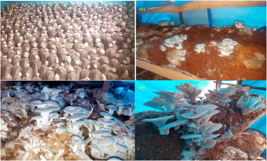

1. [Download : Download high-res image (1MB)](https://ars.els-cdn.com/content/image/1-s2.0-S2666154322000187-gr2_lrg.jpg)
2. [Download : Download full-size image](https://ars.els-cdn.com/content/image/1-s2.0-S2666154322000187-gr2.jpg)

Fig. 2. Substrate processing and mushroom fruiting procedures: (**a**) substrate bags before incubation, (**b**) [primordia](https://www.sciencedirect.com/topics/agricultural-and-biological-sciences/primordium) initiation under casing technique, (**c**) oyster production on shelf showing more runts, and (**d**) normal mushroom growth on shelf technique but simulating the casing technique.

The oyster mushroom (*[Pleurotus ostreatus](https://www.sciencedirect.com/topics/agricultural-and-biological-sciences/pleurotus-ostreatus)* (Jacq.) P. Kumm), P969 strain, was used to inoculate prepared substrates from the four staple crops at a rate of two tea spoons of inoculant per kg. This commercial mushroom strain was developed in China by the Juncao Technology and maintained at the UEA Mushroom Research Unit since 2013. This *P. ostreatus* strain showed high adaptation in the African Great Lakes region and tastes like local mushroom species, explaining its fast uptake by local communities in South-Kivu [23,27].

The experiment, with fully colonized bags, was set following a completely randomized design (CRD) with three replicates (10 filled bags represented a replicate). In this study, two factors were assessed: effects of substrate ingredients (crop residues) and the additive used. As stated above, residues from four staple crops were used for mushroom production (common bean, banana, cassava, and maize) and two additives were supplemented separately to substrates (dry cow dung and soybean flour).

The substrates obtained from the above-mentioned procedures were planted inside a hangar/barn (∼20 °C) to protect the culture from weather extremes (harsh sunny and heavy rain conditions). The casing fruiting technique (locally referred to as “gobetage”) was used although some demonstrations were done for shelf fruiting procedure during the participatory research (Fig. 2). The implement of casing technique followed procedures described by Refs. [23,27]. The casing technique showed high yield potential in previous studies conducted in South-Kivu compared to shelf fruiting technique [27]. Based on that research, the casing technique/gobetage consists of: i) digging a trench of 1 m × 1 m and 35 cm deep; ii) burying the bags containing substrates at 20 cm spacing and covering them with a thin layer of soil; and iii) arranging a shelter in the form of a small greenhouse to control climatic conditions such as heavy rains and excessive sunshine (the casing technique is better illustrated by Fig. 5). The experiment for mushroom production lasted four months, one month of incubation and three months for [fruiting body](https://www.sciencedirect.com/topics/agricultural-and-biological-sciences/fruiting-bodies) production.

To ensure appropriate soil moisture content, watering (using 30 cl tap water per substrate) was practiced twice daily until the end of the trial. Following oyster mushroom growth and yield-related parameters were recorded as directed by Ref. [23]: stipe diameter and length, pileus (cap) diameter, the total weight (in g) per bag, the number of runts (aborted individuals), and the number of clumps/individuals per substrate. The average yield presented in this study for 1 kg bag substrate is the summation of harvests on the bag from first harvest to cease. It is noteworthy that depending on substrate richness in nutrients, a multiple harvest up to four times is possible in mushroom production. These harvests were often two week-spaced with decreasing trend for the quantity harvested.

### 2.3. Data processing and analysis

Data from household survey, quantification of field yields and residues and those from experiments on oyster mushroom production were entered in Microsoft Excel 2010. Quantitative data from survey were presented by means followed by the standard deviation while frequencies were calculated for qualitative variables. The dependence between qualitative variables was assessed using the Chi<sup>2</sup> test. Analysis of variance (ANOVA) allowed comparing means of crop residues and yields for each target crop. ANOVA test allowed determining the influence of fructification substrates and supplements on mushroom yields while the Tukey HSD test was used for mean separation at 5% *p*-value threshold. Pearson's correlation analysis was later run to establish relationships among mushroom parameters. Analyses were performed using XLSTAT 2014 and R software packages [34].

## 3. Results

### 3.1. Quantification of staple crops’ residues and yields in smallholder farms

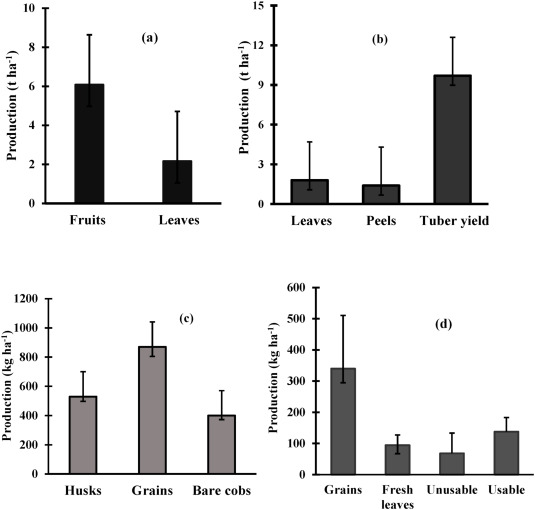

1. [Download : Download high-res image (322KB)](https://ars.els-cdn.com/content/image/1-s2.0-S2666154322000187-gr3_lrg.jpg)
2. [Download : Download full-size image](https://ars.els-cdn.com/content/image/1-s2.0-S2666154322000187-gr3.jpg)

Fig. 3. Quantification of yields and residues with respect to crop specificity: (**a**) banana, (**b**) cassava, (**c**) maize, and (**d**) common bean, as recorded at the smallholder farm scale in Mushinga, Walungu territory. Useable and unusable residues refer to common bean parts that can be used or not for mushroom production.

### 3.2. Use of crop residues in Mushinga area

As stated in the method section, field observations were coupled with interviews with farmers in the study area to gain insights on current uses of crop residues (that hold potential for valorization in mushroom production). The main activities of the household heads were agriculture (∼36.1%) and livestock farming (∼56.4%). Only ∼7.5% of surveyed households had off-farm activities for income generation such as the brick making in wetlands, artisanry, and small trade. Results on use of crop residues in the study area are presented in Table 1, Table 2. Table 1 summarizes the destination of cassava and banana residues in Mushinga, Walungu territory. Based on farmers' opinions, cassava and banana leaves were mostly cut and left on the farm (67.4%). On the other hand, farmers were using these crops’ leaves either for composting (13.7%) or feed for cow and goat (22.3%). It is noteworthy that the end destination of crop leaves significantly varied with the crop (*p* = 0.030). Cassava stems were mostly used as planting material (75.6%). Other cassava stem uses included firewood in resource-poor households (24.4%). High proportion of cassava peelings were supplied as feed to pigs (77.3%) and goats (1.7%). Other farmers chopped and left the stems on the farm to maintain adequate soil moisture (19.3%) while 1.7% of farmers had no specific use for cassava stems after harvest (Table 1).

Table 1. Current uses of residues from cassava and banana farms.

| Crop residue usage | Proportion of user households (%) Banana | Proportion of user households (%) Cassava | Proportion of user households (%) Intercropping | Proportion of user households (%) Total | χ2 | *P*-value |  |  |
| --- | --- | --- | --- | --- | --- | --- | --- | --- |
| Use for leaves |  |  |  |  |  |  |  |  |
| *Given to livestock (cow and goat)* | 61.0 | 0.0 | 6.7 | **22.3** |  |  | 22.82 | *0.030* |
| *Consumption* | 0.0 | 80.0 | 40.0 | **40.0** |  |  |  |  |
| *Sold* | 5.0 | 20.0 | 15.0 | **13.3** |  |  |  |  |
| *Left in the farm* | 26.1 | 75.4 | 100 | **67.4** |  |  |  |  |
| *Composted* | 12.9 | 28.1 | 0.0 | **13.7** |  |  |  |  |
| **Use for stems** |  |  |  |  |  |  |  |  |
| *Used as planting material* | 96.9 | 65.3 | 100 | **75.6** | 46.54 | *0.002* |  |  |
| *Household firewood* | 3.1 | 34.7 | 0.0 | **24.4** |  |  |  |  |
| **Use for peels** |  |  |  |  |  |  |  |  |
| *Feed for pigs* | 84.4 | 75.0 | 73.3 | **77.3** | 19.10 | *0.04* |  |  |
| *Feed for goat* | 0.0 | 1.4 | 6.7 | **1.7** |  |  |  |  |
| *Pseudo-stems left in the farm* | 15.6 | 23.6 | 6.7 | **19.3** |  |  |  |  |
| *No use* | 0.0 | 0.0 | 13.3 | **1.7** |  |  |  |  |

Table 2. Current uses of residues from common bean and maize farms.

| Crop residue usage | Proportion of user households (%) Maize | Proportion of user households (%) Bean | Proportion of user households (%) Intercropping | Proportion of user households (%) Total | χ<sup>2</sup> | *P*-value |  |  |
| --- | --- | --- | --- | --- | --- | --- | --- | --- |
| Use for roots |  |  |  |  |  |  |  |  |
| *Left on farm* | 59.6 | 75.0 | 51.2 | **59.1** |  |  | 8.5 | *0.052* |
| *Composted* | 8.5 | 0.0 | 0.0 | **3.7** |  |  |  |  |
| *Incinerated* | 31.9 | 25.0 | 48.8 | **37.8** |  |  |  |  |
| **Use for leaves** |  |  |  |  |  |  |  |  |
| *No use* | 100 | 5.0 | 2.3 | **35.8** | 6.9 | *0.031* |  |  |
| *Consumed* | 0.0 | 65.0 | 65.2 | **43.5** |  |  |  |  |
| *Sold* | 0.0 | 30.0 | 32.5 | **20.7** |  |  |  |  |
| **Use for other plant residues** |  |  |  |  |  |  |  |  |
| *Left on farm* | 34.0 | 30.0 | 46.5 | **38.2** | 18.5 | *0.005* |  |  |
| *Used as fodder* | 31.9 | 20.0 | 4.6 | **19.1** |  |  |  |  |
| *Composted* | 14.9 | 40.0 | 16.3 | **20.0** |  |  |  |  |
| *Incinerated* | 19.2 | 10.0 | 32.6 | **22.7** |  |  |  |  |
| **Use for pods and grains** |  |  |  |  |  |  |  |  |
| *Consumed* | 80.8 | 90.0 | 88.4 | **85.5** | 8.97 | *0.017* |  |  |
| *Sold* | 8.6 | 10.0 | 0.0 | **5.4** |  |  |  |  |
| *Other uses* | 10.6 | 0.0 | 11.6 | **9.1** |  |  |  |  |
| **Fodder sources** |  |  |  |  |  |  |  |  |
| *Farm* | 63.8 | 75.0 | 74.4 | **70.0** |  |  |  |  |
| *Divagation* | 21.3 | 15.0 | 16.2 | **18.2** |  |  |  |  |
| *Forest* | 8.5 | 5.0 | 6.9 | **7.2** |  |  |  |  |
| *No livestock* | 4.2 | 5.0 | 2.3 | **3.6** | 2.83 | *0.944* |  |  |
| *Other* | 2.1 | 0.0 | 0.0 | **0.9** |  |  |  |  |

Table 2 shows that uses of plant roots did not vary with the cropping system for crops like maize and common bean. Majority (∼59.1%) of households left maize and common bean roots on-farms for nutrient recycling. On the other hand, 3.7% farmers used belowground plant parts (roots) of maize and beans for composting, while ∼37.8 farmers incinerated them. There was a significant difference between maize and beans for the destination of crop leaves (*p* = 0.031). Maize leaves were not used at all in Mushinga, ∼43.5% households used fresh leaves of common beans for household consumption (as vegetables) while 20.7% households traded them at local markets for income generation. Other plant parts of these two crops (stems, branches, blooms, etc.) were commonly left on-farm (∼38.2%), used as feed (∼19.1%), or composted (∼20%). Another proportion of farmers incinerated these plant parts (∼22.7%) to get ash (that is currently considered as an organic amendment by local farmers). Both maize (∼80.8%) and common bean (90.0%) grains were mostly produced for household consumption. Other producers traded (∼8.6% for maize and 10.0% for common bean) or had other maize grain uses (∼10.6%) such as traditional beer production, pig feed, etc.

Concerning the fodder sources for the [livestock feed](https://www.sciencedirect.com/topics/agricultural-and-biological-sciences/livestock-feeds); most of the fodder used by farmers in Mushinga area were produced on their own farms (∼70%) or harvested from forest environments (7.2%). Of surveyed households, 3.6% had no livestock while 18.2% were letting their animals in divagation (Table 2).

### 3.3. Effects of local substrates and additives on mushroom productivity

Results in Table 3 shows that yield and yield related traits of mushroom responded differently to treatments. The substrate influenced significantly the stipe length (*p* = 0.02), the number of runts (*p* = 0.038), and the stipe diameter (*p* = 0.019). The effects of additives were significant on stipe length (*p* < 0.001), the number of runts (*p* = 0.016), the number of pileus (*p* < 0.001) and weight of mushroom (*p* < 0.001). The substrate × supplement interactions had significant influences on stipe length (*p* = 0.038), number of pileus (*p* = 0.043) and the weight of mushroom harvested per bag (*p* = 0.034).

Table 3. Yield and yield-related traits of *P. ostreatus* P969 grown on local substrates and supplements.

| **Supplements** | Substrates | Stipe length (cm) | Number of runts | Number of pileus | Number of clumps | Stipe diameter (cm) | Weight/bag (kg) |
| --- | --- | --- | --- | --- | --- | --- | --- |
| **Soybean flour** | *Banana* | 2.85 ± 0.21a | 7.55 ± 2.68b | 4.45 ± 2.45c | 1.15 ± 0.19a | 2.92 ± 0.45b | 1.14 ± 0.5b |
|  | *Cassava* | 2.25 ± 0.25b | 4,14 ± 3.19b | 11.51 ± 3.2a | 1.78 ± 0.22a | 2.97 ± 0.22b | 1.79 ± 0.36b |
|  | *Maize* | 2.92 ± 0.51a | 10.6 ± 9.0b | 7.17 ± 3.2 ab | 1.43 ± 0.71a | 3.19 ± 0.19a | 2.23 ± 0.5 ab |
|  | *Common bean* | 2.87 ± 0.71a | 14.0 ± 9.4a | 6.88 ± 5.2 ab | 1.17 ± 0.21a | 3.21 ± 0.32a | 2.17 ± 0.4 ab |
| **Cow dung** | *Banana* | 3.33 ± 0.01a | 14.05 ± 5.49a | 6.21 ± 5.4b | 1.19 ± 0.19a | 2.61 ± 0.13b | 1.19 ± 0.26b |
|  | *Cassava* | 2.96 ± 0.19b | 11.69 ± 1.46a | 9.76 ± 4.5a | 1.17 ± 0.23a | 2.81 ± 0.27b | 1.18 ± 0.35b |
|  | *Maize* | 3.01 ± 0.5a | 11.6 ± 10.0a | 7.09 ± 3.1a | 1.49 ± 0.7a | 3.45 ± 0.33a | 2.49 ± 0.5a |
|  | *Common bean* | 2.9 ± 0.6b | 12.6 **±** 9.4a | 6.57 ± 4.9a | 1.2 ± 0.5a | 2.80 ± 0.39b | 1.84 ± 0.3 ab |
| **CV (%)** |  | 12.5 | 7.64 | 18.7 | 5.78 | 9.34 | 15.1 |
| *P*-value | *Substrates* | *0.020** | *0.0381** | *0.*0018hs | *0.*055ns | *0.0198** | *0.*1375ns |
|  | *Supplements* | *<0.001**** | *0.016*** | *<0.001**** | *0.*120ns | *0.*604ns | *<0.001**** |
|  | *Interaction* | *0.038** | *0.057* | *0.043** | *0.*062ns | *0.*052ns | *0.034** |
| **Tukey HSD** |  | **0.43** | **2.4** | **2.8** | **0.3** | **0.8** | **0.4** |

*: significant (p<5%), **: highly significant (p<1%), ***: very highly significant (p<0.1%), **ns:** not significant (p>5%), values with different letters under the same column/parameter are statistically different at 5% p-value threshold according to Tukey HSD mean separation test, SD: standard deviation, CV: coefficient of variation.

Substrates from maize residues combined with cow dung produced highest *[Pleurotus](https://www.sciencedirect.com/topics/agricultural-and-biological-sciences/pleurotus)* mushroom yield per bag (2.4 kg kg<sup>−1</sup>) than those from the common bean combined with soybean as supplement (2.2 kg kg<sup>−1</sup>). There was no difference between mushroom productions from maize and common bean based substrates when the soybean flour was used on them as supplement. Common bean with cow dung allowed producing ∼1.8 kg kg<sup>−1</sup> of *Pleurotus,* not statistically different from cassava peels combined with soybean flour. These results showed also that banana leaves (either with soybean flour (1.1 kg kg<sup>−1</sup>) or with cow dung (1.2 kg kg<sup>−1</sup>)) had the least productivity in *Pleurotus* mushroom. Cassava peels combined with cow dung presented a similar low production level (1.2 kg kg<sup>−1</sup>). Weight of mushroom per bag was positively correlated with the number of pileus (r = 0.5463**). The number of pileus itself depended on the number of runts (r = 0.4959**) and the stipe diameter (r = −0.3473*). Other parameters had no significant effect on mushroom yield per bag (Table 4). Fig. 4 shows *Pleurotus* runts (Fig. 4a), *Pleurotus* in growth stage (Fig. 4c), normal growth combined with runts (Fig. 4b), and normal growth without runts (Fig. 4d) while Fig. 4e shows the optimum development condition of mushroom under casing/gobetage technique.

Table 4. Pearson's correlation coefficients among mushroom production parameters.

| Parameters | Stipe length (cm) | Number of runts | Number of pileus | Number of clumps | Weight (g) |
| --- | --- | --- | --- | --- | --- |
| Number of runts | 0.2460ns |  |  |  |  |
| Number of pileus | 0.1707ns | 0.4959** |  |  |  |
| Number of clumps | 0.0946ns | 0.2544ns | 0.2592ns |  |  |
| Weight (kg/bag) | 0.0675ns | 0.2117ns | 0.5463** | −0.0913ns |  |
| Stipe diameter (cm) | 0.0025ns | −0.3233ns | −0.3473* | 0.0856ns | 0.2188ns |

*: significant (p<5%), **: highly significant (p<1%), **ns:** not significant (p>5%).

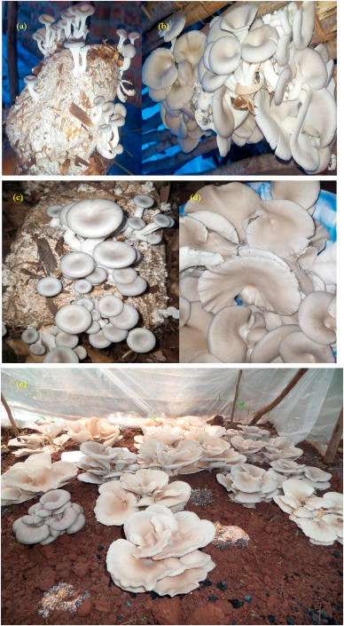

1. [Download : Download high-res image (2MB)](https://ars.els-cdn.com/content/image/1-s2.0-S2666154322000187-gr4_lrg.jpg)
2. [Download : Download full-size image](https://ars.els-cdn.com/content/image/1-s2.0-S2666154322000187-gr4.jpg)

Fig. 4. The combined effect of substrates and supplements on oyster mushroom production: (**a**) substrates with runts, (**b**) *Pleurotus* growth combined with runts, (**c**) *Pleurotus* growth at primordial development stage, (**d)** mature mushroom at the final growth stage, (**e**) optimum growth aspect under casing production technique.

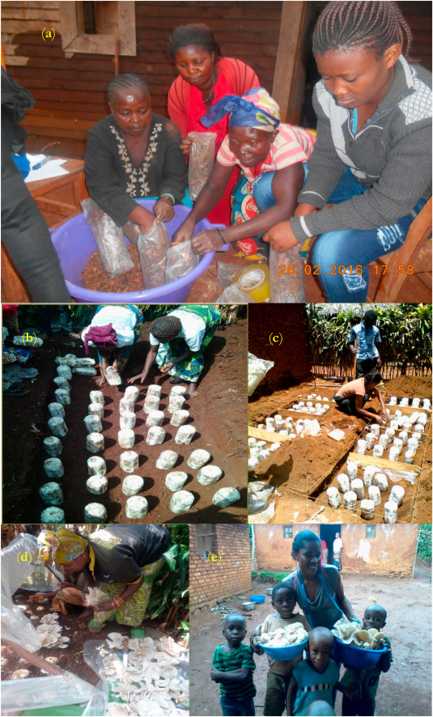

1. [Download : Download high-res image (3MB)](https://ars.els-cdn.com/content/image/1-s2.0-S2666154322000187-gr5_lrg.jpg)
2. [Download : Download full-size image](https://ars.els-cdn.com/content/image/1-s2.0-S2666154322000187-gr5.jpg)

Fig. 5. Women association members growing mushrooms in rural South-Kivu using the casing technique after participating in research activities: (**a**) bagging of substrates, (**b**) aligning substrates in trench, (**c**) covering aligned substrates with thin soil layer, (**d**) harvesting stage and (**e**) transport of harvested mushroom to the household.

## 4. Discussion

### 4.1. Smallholder farmers’ fields are characterized by low yields and biomass productivity in eastern DRC

Results from the monitoring of farmers' fields showed that there is low yield and low biomass productivity in smallholder farms in the study area. None of the staple crops reached its full potential under farmers’ field conditions. For example, cassava and common bean yields were only ∼10 and 0.3 t ha<sup>−1</sup>, respectively, far below their potentials in the country, which can reach 50 and 2–5 t ha<sup>−1</sup>, respectively [7,35,36]. The trends were the same for banana and maize yields (∼6.1 and < 1 t ha<sup>−1</sup>, respectively) while their potentials are far above (15–50 and 2–6 t ha<sup>−1</sup>, respectively) [17]. Several factors could explain underperformances of those staple crops in rural South-Kivu areas: high disease pressure on predominantly used [landraces](https://www.sciencedirect.com/topics/agricultural-and-biological-sciences/landrace) [7,[36], [37], [38], [39], [40]], absence of proper soil management practices [18,19,37,41,42]; suboptimal cropping practices, absence of incentives and subsidies from the government, weakness of extension services in introducing promising technologies, faulty seed delivery systems [7,29,43], [soil erosion](https://www.sciencedirect.com/topics/agricultural-and-biological-sciences/soil-erosion) and overexploitation as a result of high population growth and climate changes [20,33,42,44], low crop-livestock integration [32], etc. These production-limiting factors seriously threaten food security in rural areas since more than 80% of the South-Kivu populations depend on these crops for food and income.

Not only that yield is affected, some of these constraints such as low soil fertility, disease, erratic rainfall, etc. often lead to low [biomass production](https://www.sciencedirect.com/topics/agricultural-and-biological-sciences/biomass-production) which could have provided alternative food and income sources through mushroom production or used as fodder or compost. Therefore, strategies should be devised to support smallholder farming in eastern DRC to improve food security status of household. It is noteworthy that family farming by smallholder farmers in the region is an effective means of eradicating poverty and malnutrition, feeding the communities by providing up to 80% of their food [43]. Since crop yields and biomass production are both low and associated with same causing factors, adequate agronomic practices should be promoted to increase yield and avail sufficient biomass for mushroom production. Choice of better varieties, optimum [fertilizer application](https://www.sciencedirect.com/topics/agricultural-and-biological-sciences/fertilizer-application), control of weed, [foliar diseases](https://www.sciencedirect.com/topics/agricultural-and-biological-sciences/foliar-diseases), and pests, etc. would help increase yield and biomass production in eastern DRC.

Low yields recorded in smallholder farms in South-Kivu agree with several previous reports in the study area [11,[45], [46], [47]]. In addition to yield of target plant parts such as fruits (bunch), grains, and tubers, this study is among the rarest that quantified other useable plant parts in eastern DRC. It is noteworthy that the South-Kivu has unique preference criteria for staple crop varieties. As stated by Ref. [7]; crop leaves of most staple crops (such as cassava, sweet potato, common bean, and pumpkin) are consumed in eastern DRC and are among preference criteria for these staple crops’ varieties adoption among smallholder farmers. Therefore, important details are lost when yield assessment is limited on grains, tubers, or bunch of fruits. These often non-quantified crop parts, such as leaf biomass (for both cassava and beans), are however, instrumental in maintaining food and income security among rural smallholder farmers, through their consumption as vegetables or trade at local markets for income generation [7].

The average crop yields reported in this study, which directly monitored farmers’ fields with no external input from the investigators/researchers, are significantly lower compared to those reported by national and international research institutions such as INERA and IITA for the study area. This shows that yields of staple crops are often overestimated by experiments compared to the farmer realities even when trials are in the same location as the farmer fields. The quantification methods used in this study should, therefore, be adopted when yield at smallholder farm scale is needed in South-Kivu to avoid overestimation which could lead to inappropriate decision-making and biased policies towards supporting farmers.

### 4.2. Strategic use of crop residues could result in extra food and income generation

Use of crop residues in eastern DRC varied with crops and target plant parts. In the case of banana, a large portion of residues was abandoned in the field after harvest, while cassava and common bean fresh leaves are consumed by households or sold in local markets. Four major uses of residues were reported for the four staple crops: composting, fodder for livestock, incineration (burning) to obtain ash for use as a soil amendment, and nutrient recycling through burying residues as organic matter (Table 1, Table 2). All of these current uses of crop residues do not directly improve the household income or food nutrition status. To reduce competition with other uses, common bean residues (except leaves), maize residues (all the plant) and cassava peels can be converted in substrates for use in mushroom production. Although the conversion requires several efforts and knowledge to process residues in substrates, it is a highly profitable valorization option since the mushroom produced is highly nutritious [24,27] and can be sold to cover famers’ basic needs or reinvested in farming activities. The other advantage is that after mushroom production, substrates can still be converted in compost for soil amendment or feed for livestock and fish nutrition [24].

Residues/wastes from major staple crops in South-Kivu are among those listed as promising candidates for recycling and valorization elsewhere. For instance, Refs. [48,49] mentioned that residues of crops such as cereal straws, naked [corn cobs](https://www.sciencedirect.com/topics/agricultural-and-biological-sciences/corn-cob), cotton stalks, various grasses, and reed stems, maize and sorghum stover, vine prunings, [sugarcane bagasse](https://www.sciencedirect.com/topics/agricultural-and-biological-sciences/sugarcane-bagasse), coconut and banana residues, [corn husks](https://www.sciencedirect.com/topics/agricultural-and-biological-sciences/corn-husks), [coffee pulp](https://www.sciencedirect.com/topics/agricultural-and-biological-sciences/coffee-pulp) and coffee husk, [cotton seed](https://www.sciencedirect.com/topics/agricultural-and-biological-sciences/cottonseed) and [sunflower seed](https://www.sciencedirect.com/topics/agricultural-and-biological-sciences/sunflower-seed) hulls, peanut shells, rice husks, waste paper, wood sawdust, and chips, etc. are some examples of agricultural residues and by-products that can be recycled and valorized in useful products by chemical or biological processes. Their chemical properties (such as lignocellulosic agricultural residues composition) make them a substrate of enormous biotechnological value, and in our case, for oyster mushroom production. Mushroom cultivation has proved its economic potential and ecological importance for efficient utilization, value-addition, and [biotransformation](https://www.sciencedirect.com/topics/agricultural-and-biological-sciences/bioconversion) of agro-industrial residues. Production and commercialization of mushrooms, at a large or small scale, is an efficient and relatively short biological process of food protein recovery from negative value lignocellulosic materials, exploiting the degrading capabilities of mushroom fungi [48,49].

In our case study, we supported the idea that one of the best ways of valorizing crop residues is through oyster mushroom production. The same conclusions were reached in western provinces of DRC as it was demonstrated an economic and ecological potential of converting local staple crop residues such as the [wood chips](https://www.sciencedirect.com/topics/agricultural-and-biological-sciences/wood-chips) and sawdust, [wheat bran](https://www.sciencedirect.com/topics/agricultural-and-biological-sciences/wheat-bran), and slaked lime into high quality mushroom substrates. Residues of staple crops in eastern DRC allowed achieving higher *[Pleurotus](https://www.sciencedirect.com/topics/agricultural-and-biological-sciences/pleurotus)* yields as compared to those reported by Ref. [50] in using beech sawdust (275.22 g), wheat straw (215.87 g), and olive pruning residues (134.87 g), with biological efficiency of 77.3, 39.73 and 56.79%, respectively. Yields (0.22–0.64 kg kg<sup>−1</sup>) achieved by Ref. [23]; under station, are lower than those obtained under this participatory research in farmer environments (>1 kg kg<sup>−1</sup> of substrates). Like in that previous study, best results were obtained using manure/cow dung (107 g/stipe). Adding cow dung as supplement to substrates allowed increasing the substrate productivity by 42.8% compared to the control where no additive was added. Although adding soybean to substrates provided good results, especially in substrates from crop residues with low nitrogen content, its use in the study area for mushroom production would be challenged by its multipurpose status. For instance, soybean is commonly used in households for tea, porridge, in soup to enrich food with protein, soybean milk or consumed roasted. It would not, therefore, be practical and cost-effective to recommend it for use as supplement in the study area. Since crop-livestock integration has long been promoted in the study area [32], we strongly recommend cow dung as additive to substrate since it is abundantly available at no or low cost all over the study area [23]. Previous studies in controlled environment discouraged use of soybean flour on residues with high nitrogen content since it favored high infestations by competitive fungi and bacteria in addition to increasing the abortion rates (number of runts per substrate bag) [23,27,51].

Based on previous experiences, high nitrogen content and the low level of moisture retention create an unfavorable condition for the growth and development of mushroom. This often results in poor response to increasing doses of nitrogenous additives, due to oversaturation of the substrate in nitrogen, leading to high substrate infections and rots [23]. Differences in substrate responses are not only linked to chemical composition of used crop residues but also to the texture and compaction of the substrate in the bag. When the substrate is too dense as it is often the case for common bean residues; the aeration is reduced and the colonization by the mycelium is slow. On the other hand, dispersed substrate, such as that from banana leaves, fails to retain sufficient moisture for proper mycelium development. In all the cases, the texture of used residues for mushroom substrates should allow the passage of oxygen and retention of sufficient water for mushroom development without being too compact [23,52].

### 4.3. Promotion of mushroom production in eastern DRC is a key asset for achieving food security

Several case studies have pointed to the importance of mushroom production as a source, not only of [dietary protein](https://www.sciencedirect.com/topics/agricultural-and-biological-sciences/dietary-protein) but also as an important source of household income [24,27,53]. For the case of South-Kivu, eastern DRC, which is characterized by chronic [micronutrient deficiencies](https://www.sciencedirect.com/topics/agricultural-and-biological-sciences/micronutrient-deficiency) (e.g. zinc, iron, [vitamin A](https://www.sciencedirect.com/topics/agricultural-and-biological-sciences/retinol), protein) among the majority of its populations [6,13,14,54], the production of mushrooms by valorizing crop residues is an alternative way of combating hidden hunger and poverty among resource-poor populations who can hardly afford food diversification. This work sets up simple methods of obtaining local substrates to improve production and easy accessibility to nutritious food from mushroom. Scaling mushroom production and consumption in eastern DRC would be a resilient approach against production-limiting factors (climate hazards, diseases and pests, low soil fertility, high demographic pressure) that undermine productivity of conventional staple crops [24].

As stated earlier, previous efforts to promote mushroom production in South-Kivu proved its potential in contributing to food security and poverty alleviation among resource-poor populations [12]. In addition to this study, promising culture practices (optimum substrate composition, additive doses, appropriate and cost-effective pasteurization methods and timing, fruiting techniques, adapted mushroom strains and species, etc.) have been developed for high mushroom productivity both in station and farmer conditions by the UEA Mushroom Research Unit (Fig. 5), and need to be adopted locally and nationally for sustainable mushroom production. Studies on value-addition have also been initiated, including proper conservation methods of fresh mushroom to prevent rotting and use of mushroom flour in bakery production to raise the nutritional values of bakery products [12]. Previous studies demonstrated the effectiveness of fortifying [cassava flour](https://www.sciencedirect.com/topics/agricultural-and-biological-sciences/cassava-flour) with *Pleurotus* flour in bakery production. This led to a good consistency and high protein and energy contents of local breads, and thus holds potential in improving the nutritional status of populations in non-wheat producing regions such as eastern DRC. Availing nutritious food products to rural and resource-poor farmers has been regarded as an efficient strategy for combating malnutrition, strengthening food security, and boosting economic growth by optimizing human capital productivity [55]. There is, therefore, a need to promote local resources in energy-balanced and proteinous food to populations, especially in regions such as eastern DRC where the production of energy and protein-rich products such as legumes and cereals is very low. In this work, the production of oyster mushrooms through the valorization of crop residues is presented as a way out to improve household income (through the trade of produced mushroom) and especially through household consumption (Table 5). Producing mushroom by rural households would also reduce pressure on natural resources such as forest as they will be no need to invade forests for mushroom harvest.

Table 5. Unadjusted cost-benefit estimate for valorizing staple crop residues in mushroom production in eastern DRC.

[output not shown]

**a**

This is unadjusted estimation cost based on in-station data; it does not include investment and administrative costs.

**b**

The gross value was calculated using the minimum price of mushroom at local market (1 kg = 2.5–5$, we considered the minimum price (2.5$/kg) since this study was conducted in rural areas) and it ignored probable losses during processing, conservation and transport. It is noteworthy that the average field size in the study area is 0.6 ha per household. Such activity should, therefore, be done in farmer cooperatives for more profitability. Due to difficulty of estimating cost in [subsistence farming](https://www.sciencedirect.com/topics/agricultural-and-biological-sciences/subsistence-agriculture) for staple crops among smallholder farmers, cost-benefit estimates were not presented to give a picture on income gained from agriculture by these farmers and thus to evaluate the proportion of income that could result from crop residue valorization.

## 5. Conclusions

This study showed that yields and [biomass production](https://www.sciencedirect.com/topics/agricultural-and-biological-sciences/biomass-production) of staple crops are low in farmer fields compared to their potential in South-Kivu. Current uses of staple crop residues are not directly impacting household income and food security due to lack of knowledge on profitable residue valorization options. Residues of staple crops, combined with local additives, had different mushroom yield potentials in South-Kivu. Maize naked cobs gave the highest mushroom yields while banana leaves had the lowest potential. Most productive substrates should, therefore, be promoted for mushroom production to improve income and food security of smallholder farmers in eastern DRC.

## Ethics approval and consent to participate

Not applicable.

## Consent for publication

Not applicable.

## Availability of data and materials

The authors want to declare that they can submit the data at whatever time based on your request. The data used for the current study are available from the corresponding author on reasonable request.

## Funding

Not applicable.

## Authors' contributions

OKK and ASL did data collection, GCB and JMM conceived and coordinated the study, did the statistical analysis and drafted the manuscript, SM, ABZ and GNM supervised the research and helped revising the manuscript. All authors read and agreed on the last version of the manuscript.

## Declaration of competing interest

No conflict of interest.

## Acknowledgments

Financial support for data collection from “Pain pour le Monde” through DIOBASS platform and UEA is gratefully acknowledged. This research project was conducted with active participation of farmer organizations in Mushinga to which we are grateful. We thank the anonymous reviewers and editors for their constructive suggestions and comments to improve the quality of this manuscript.

## Abbreviations

**DRC**

Democratic Republic of Congo

**IITA**

International Institute of Tropical Agriculture

**INERA**

Institut National pour l’Etude et la Recherche Agronomiques

**HSD**

Honestly Significant Differences of Means

**UEA**

Université Evangélique en Afrique

**SSA**

Sub-Saharan Africa

**FAO**

Food and Agriculture Organization

**ANOVA**

Analysis of variance

## References

**[1]**

African Union

Malabo Declaration on Accelerated Agricultural Growth and Transformation for Shared Prosperity and Improved Livelihoods. African Union, Addis Ababa, Ethiopia

(2014)

Google Scholar

**[2]**

United Nations

Transforming Our World: the 2030 Agenda for Sustainable Development; 2015 A/RES/70/1

United Nations, San Francisco, CA, USA (2015)

[Google Scholar](https://scholar.google.com/scholar?q=Transforming%20Our%20World:%20the%202030%20Agenda%20for%20Sustainable%20Development;%202015%20ARES701)

**[3]**

S.O. Igbinedion, S.O. Abusomwan

Sub-Saharan Africa and the challenges of poverty eradication: contemporary issues and policy framework

Int. J. Dev. Sustain., 3 (12) (2014), pp. 2206-2217

[View in Scopus](https://www.scopus.com/inward/record.url?eid=2-s2.0-85087928428&partnerID=10&rel=R3.0.0)Google Scholar

**[4]**

FAO

New UN report reveals that hunger in Africa continues to rise

https://www.fao.org/news/story/en/item/1180443/icode/ (2019), Accessed 21st Oct 2021

[Google Scholar](https://scholar.google.com/scholar_lookup?title=New%20UN%20report%20reveals%20that%20hunger%20in%20Africa%20continues%20to%20rise&publication_year=2019&author=FAO)

**[5]**

G. Kankwanda, T. Makabu Ma Nkenda, B. Nilsson, F. Roubaud, C. Torelli, J.M. Wachsberger

Le marché du travail en République Démocratique du Congo en 2012: *Principaux résultats de la Phase 1 de l'Enquête 1*

(2014), pp. 2-3

[View in Scopus](https://www.scopus.com/inward/record.url?eid=2-s2.0-85125694075&partnerID=10&rel=R3.0.0)Google Scholar

**[6]**

R.M. Kambale, G.A. Ngaboyeka, J.N. Ntagazibwa, M.H.I. Bisimwa, L.Y. Kasole, V. Habiyambere, V.B. Kubuya, J.K. Kasongo, E. André, D. Van der Linden

Severe acute malnutrition in children admitted in an Intensive Therapeutic and Feeding Centre of South Kivu, Eastern Democratic Republic of Congo: why do our patients die?

PLoS One, 15 (7) (2020), p. e0236022

[CrossRef](https://doi.org/10.1371/journal.pone.0236022)[View in Scopus](https://www.scopus.com/inward/record.url?eid=2-s2.0-85088218279&partnerID=10&rel=R3.0.0)Google Scholar

**[7]**

J.M. Mondo, A.B. Irenge, R.B. Ayagirwe, P.M. Dontsop-Nguezet, K. Karume, E. Njukwe, S.M. Mapatano, P.M. Zamukulu, G.C. Basimine, E.M. Musungayi, H.K. Mbusa, L.M. Kazamwali, R. Civava, G.N. Mushagalusa

Determinants of adoption and farmers' preferences for cassava varieties in Kabare territory, Eastern Democratic Republic of Congo

Am. J. Rural Dev., 7 (2) (2019), pp. 44-52

[View in Scopus](https://www.scopus.com/inward/record.url?eid=2-s2.0-85085874827&partnerID=10&rel=R3.0.0)[Google Scholar](https://scholar.google.com/scholar?q=Determinants%20of%20adoption%20and%20farmers%20preferences%20for%20cassava%20varieties%20in%20Kabare%20territory,%20Eastern%20Democratic%20Republic%20of%20Congo)

**[8]**

J.M. Mondo, G.B. Chuma, P.B. Kwalya, S.A. Balagizi, S.S. Ndjadi, Y. Mugumaarhahama, A.Z. Balezi, K. Karume, G.N. Mushagalusa, R.M. Civava

Neglected and underutilized crop species in Kabare and Walungu territories, Eastern DR Congo: identification, uses and socio-economic importance

J. Agric. Food Res., 6 (2021), p. 100234

[View PDF](https://www.sciencedirect.com/science/article/pii/S2666154321001368/pdfft?md5=897e7ab2d70339ab3efecdf8bb60e0b4&pid=1-s2.0-S2666154321001368-main.pdf)[View article](https://www.sciencedirect.com/science/article/pii/S2666154321001368)[View in Scopus](https://www.scopus.com/inward/record.url?eid=2-s2.0-85118902541&partnerID=10&rel=R3.0.0)Google Scholar

**[9]**

SNSA

Annuaire des statistiques agricoles (2010–2015) : Ministère de l'Agriculture et du Développement Rural, Secrétariat général à l'Agriculture, Pêche et Elevage, Kinshasa, DRC

vol. 2016 (2015), p. 153

Google Scholar

**[10]**

B.G. Chuma, B.A. Ndeko, B. Mulalisi, B.F. Safina, S.S. Ndjadi, N.G. Mushagalusa

Post-harvest constraints of Solanaceae species produced in Kabare wetlands, Eastern Democratic Republic of Congo

Agric. Res. (2021), pp. 1-12, 10.1007/s40003-021-00586-4

[View in Scopus](https://www.scopus.com/inward/record.url?eid=2-s2.0-85137090394&partnerID=10&rel=R3.0.0)Google Scholar

**[11]**

W. Munyahali, P. Pypers, R. Swennen, J. Walangululu, B. Vanlauwe, R. Merckx

Responses of cassava growth and yield to leaf harvesting frequency and NPK fertilizer in South Kivu, Democratic Republic of Congo

Field Crop. Res., 214 (2017), pp. 194-201

[View PDF](https://www.sciencedirect.com/science/article/pii/S0378429017306421/pdfft?md5=282bd7e5fc69187edaae758165016a3d&pid=1-s2.0-S0378429017306421-main.pdf)[View article](https://www.sciencedirect.com/science/article/pii/S0378429017306421)[View in Scopus](https://www.scopus.com/inward/record.url?eid=2-s2.0-85031721613&partnerID=10&rel=R3.0.0)Google Scholar

**[12]**

N.P. Irakiza, B.G. Chuma, L.T. Zongwe, M.M. Aganze, M.J. Mondo, Z.P. Kulimushi, S. Mapatano, Z.A. Balezi, N.G. Mushagalusa

Fortification with mushroom flour (Pleurotus ostreatus (Jacq.) P.Kumm) and substitution of wheat flour by cassava flour in bread making: nutritional and technical implications in Eastern DR Congo

Agric. Food Secur., 301 (2021), 10.1186/s40066-021-00301-0

Google Scholar

**[13]**

K. Muller, S. Alice, S. Charles, M. Shimwela, N. Deborah, E. Beatrice

Agronomic performance of provitamin A-rich banana cultivars in Burundi and the Democratic Republic of Congo

Afr. J. Agric. Res., 17 (9) (2021), pp. 1209-1220

[View in Scopus](https://www.scopus.com/inward/record.url?eid=2-s2.0-85125746984&partnerID=10&rel=R3.0.0)Google Scholar

**[14]**

D.R.C. HarvestPlus

Available online:

http://www.harvestplus.org/content/iron-beans-dr-congo (2009), Accessed 21st Oct 2021

**[15]**

N. Petry, E. Boy, J.P. Wirth, R.F. Hurrell

The potential of the common bean (*Phaseolus vulgaris*) as a vehicle for iron biofortification

Nutrients, 7 (2) (2015), pp. 1144-1173

[CrossRef](https://doi.org/10.3390/nu7021144)[View in Scopus](https://www.scopus.com/inward/record.url?eid=2-s2.0-84922805018&partnerID=10&rel=R3.0.0)[Google Scholar](https://scholar.google.com/scholar?q=The%20potential%20of%20the%20common%20bean%20%20as%20a%20vehicle%20for%20iron%20biofortification)

**[16]**

A. Buzera, P. Kinyanjui, J. Ishara, D. Sila

Physical and cooking properties of two varieties of bio-fortified common beans (*Phaseolus vulgaris* L) grown in DR Congo

IISTE Food Sci. Qual. Manag., 71 (2018), pp. 1-12

[View in Scopus](https://www.scopus.com/inward/record.url?eid=2-s2.0-85125542120&partnerID=10&rel=R3.0.0)[Google Scholar](https://scholar.google.com/scholar?q=Physical%20and%20cooking%20properties%20of%20two%20varieties%20of%20bio-fortified%20common%20beans%20%20grown%20in%20DR%20Congo)

**[17]**

FAOSTAT

Available online:

http://www.fao.org/faostat/en/#data/QL (2021), Accessed 21st Oct 2021

**[18]**

B.G. Chuma, B.F. Safina, N.A. Byamungu, W. Nuru, B. Mulalisi, E.M. Bagula, M.J. Mondo, K.A. Lubobo, N.G. Mushagalusa

Optimal fertiliser dose and nutrients allocation in local and biofortified bean varieties grown on ferralsols in eastern Democratic Republic of the Congo

Cogent Food Agric., 6 (1) (2020), p. 1805226

Google Scholar

**[19]**

B.I. Kayani, B. Agumas, M. Musyoki, G. Nziguheba, C. Marohn, M. Benz, B. Vanlauwe, G. Cadisch, F. Rasche

Market access and resource endowment define the soil fertility status of smallholder farming systems of South‐Kivu, DR Congo

Soil Use Manag., 37 (2) (2021), pp. 353-366

[Google Scholar](https://scholar.google.com/scholar?q=Market%20access%20and%20resource%20endowment%20define%20the%20soil%20fertility%20status%20of%20smallholder%20farming%20systems%20of%20SouthKivu,%20DR%20Congo)

**[20]**

G.N. Mushagalusa, K. Karume, J.M. Mondo, A.B. Ndeko

Situation de référence de l’agro-écologie dans les zones d’intervention du Consortium CPR Idjwi-3ème CBCA, IADL ASBL

Plate-forme DIOBASS et CAPA-CBCA au Sud-Kivu. Rapport de consultance, Université Evangélique en Afrique, Bukavu, DRC (2020), p. 160

[View in Scopus](https://www.scopus.com/inward/record.url?eid=2-s2.0-85109899023&partnerID=10&rel=R3.0.0)[Google Scholar](https://scholar.google.com/scholar?q=Situation%20de%20r%C3%A9f%C3%A9rence%20de%20lagro-%C3%A9cologie%20dans%20les%20zones%20dintervention%20du%20Consortium%20CPR%20Idjwi-3%C3%A8me%20CBCA,%20IADL%20ASBL)

**[21]**

N.G. Mushagalusa, K. Karume, B. Ndusha, A. Basengere, A. Bayisha, B.A. Bisuri, B. Chimanuka, G. Banswe

Building the Evidence Base on the Agricultural Nutrition Nexus: Democratic Republic of Congo. CTA Working Paper

17/10, CTA, Wageningen (2017)

Google Scholar

**[22]**

W.A. Bapolisi, G. Ferrari, G. Bisimwa, S. Merten

Gendered determinants of food insecurity in ongoing regional conflicts, North and South Kivu, the Democratic Republic of Congo

Agric. Food Secur., 10 (1) (2021), pp. 1-9

[View in Scopus](https://www.scopus.com/inward/record.url?eid=2-s2.0-85125721892&partnerID=10&rel=R3.0.0)Google Scholar

**[23]**

G.N. Mushagalusa, J.M. Mondo, G.B. Masangu, S.C. Lutwamuzire, C. Sambili, E.M. Bagula, A.Z. Balezi

Effects of increasing additive doses on the productivity of two strains of *Pleurotus ostreatus* (Jacq.) P. Kumm. under the casing technique; and on local substrates in the DR Congo

Tropicultura, 35 (2) (2017), pp. 102-109

Google Scholar

**[24]**

P. Kiyuku, S. Dibaluka, J. Degreef

Cultiver des champignons dans la région des Grands Lacs africains : Guide pour vulgarisateurs et petits producteurs en milieu paysan

Jardin botanique de Meise, Nieuwelaan, Meise, Belgique (2020), p. 56, 10.5281/zenodo.3941509

[View in Scopus](https://www.scopus.com/inward/record.url?eid=2-s2.0-85125693209&partnerID=10&rel=R3.0.0)Google Scholar

**[25]**

P. Kiyuku, S. Bigawa

Production de Pennisetum sp. et son utilisation pour la culture de Pleurotus ostreatus au Burundi. VertigO-la revue électronique en sciences de l'environnement, (Hors-série 17)

https://doi.org/10.4000/vertigo.13948 (2013)

Google Scholar

**[26]**

J. Mondo, A. Balezi, V. Mugomoka, L. Zigashane, E. Bagula, T. Kashosi, G. Mushagalusa

Effets des milieux de culture (PDA, SDA, SPDA, blé et maïs) sur la productivité in vitro de la souche P969 du *Pleurotus ostreatus* (Jacq.) P. Kumm

Afrique Sci., 12 (4) (2016), pp. 374-381

[View in Scopus](https://www.scopus.com/inward/record.url?eid=2-s2.0-85094132727&partnerID=10&rel=R3.0.0)[Google Scholar](https://scholar.google.com/scholar?q=Effets%20des%20milieux%20de%20culture%20%20sur%20la%20productivit%C3%A9%20in%20vitro%20de%20la%20souche%20P969%20du%20Pleurotus%20ostreatus%20%20P.%20Kumm)

**[27]**

M.J. Mondo, M.E. Bagula, Z.A. Balezi, N.G. Mushagalusa

Effets des substrats à base de fanes de haricot et de feuilles de bananier sur la productivité des souches de *Pleurotus ostreatus* (P969 et HK51) sur étagère et gobetage

VertigO-la revue électronique en sciences de l'environnement (2016), 10.4000/vertigo.16899

Google Scholar

**[28]**

H.E. Beck, N.E. Zimmermann, T.R. McVicar, N. Vergopolan, A. Berg, E.F. Wood

Present and future Köppen-Geiger climate classification maps at 1-km resolution

Sci. Data, 5 (1) (2018), pp. 1-12, 10.1038/sdata.2018.214

Google Scholar

**[29]**

Y. Mugumaarhahama, J.M. Mondo, M.C. Cokola, S.S. Ndjadi, V.B. Mutwedu, L.M. Kazamwali, N.C. Cirezi, G.B. Chuma, A.B. Ndeko, R.B.B. Ayagirwe, R. Civava

Socio-economic drivers of improved sweet potato varieties adoption among smallholder farmers in South-Kivu Province, DR Congo

Sci. Afric., 12 (2021), p. e00818

[View PDF](https://www.sciencedirect.com/science/article/pii/S2468227621001228/pdfft?md5=f2e96f275af7c2f952435f8e620a9ee6&pid=1-s2.0-S2468227621001228-main.pdf)[View article](https://www.sciencedirect.com/science/article/pii/S2468227621001228)[View in Scopus](https://www.scopus.com/inward/record.url?eid=2-s2.0-85109826405&partnerID=10&rel=R3.0.0)Google Scholar

**[30]**

J. Usungo-Ulingu

Réseau routier, pression démographique et espaces agraires dans l’hinterland rural de la ville de Bukavu, en RD Congo (1921-2012)

Parmentier (Ed.), Etudes et bibliographies d’histoire environnementale: Belgique-Nord de la France-Afrique centrale. Actes des 2e RBel, Namur, Décembre 2012, Namur, Belgium (2016), pp. 245-252

2016

[View in Scopus](https://www.scopus.com/inward/record.url?eid=2-s2.0-85125697332&partnerID=10&rel=R3.0.0)[Google Scholar](https://scholar.google.com/scholar?q=R%C3%A9seau%20routier,%20pression%20d%C3%A9mographique%20et%20espaces%20agraires%20dans%20lhinterland%20rural%20de%20la%20ville%20de%20Bukavu,%20en%20RD%20Congo)

**[31]**

M.E. Bagula, P. Pypers, N.G. Mushagalusa, J.B. Muhigwa

Assessment of fertilizer use efficiency of maize in the weathered soils of Walungu District, DR Congo

Challenges and Opportunities for Agricultural Intensification of the Humid Highland Systems of Sub-saharan Africa, Springer, Cham (2014), pp. 187-199

[CrossRef](https://doi.org/10.1007/978-3-319-07662-1_16)[View in Scopus](https://www.scopus.com/inward/record.url?eid=2-s2.0-85125752383&partnerID=10&rel=R3.0.0)Google Scholar

**[32]**

P. Zamukulu, R. Ayagirwe, A. Ndeko, E. Bagula, J. Mondo, D. Ganza, D.K. Musale, G.N. Mushagalusa

Contraintes et opportunités de l’intégration agriculture-élevage à Mushinga dans l'Est de la RD Congo

J. Anim. Plant Sci., 41 (3) (2019), pp. 7000-7014

[View in Scopus](https://www.scopus.com/inward/record.url?eid=2-s2.0-85115228509&partnerID=10&rel=R3.0.0)[Google Scholar](https://scholar.google.com/scholar?q=Contraintes%20et%20opportunit%C3%A9s%20de%20lint%C3%A9gration%20agriculture-%C3%A9levage%20%C3%A0%20Mushinga%20dans%20lEst%20de%20la%20RD%20Congo)

**[33]**

N.G. Mushagalusa, K. Karume, E. Bagula, M.J. Mondo, R. Ntole, O.O. Karume, C. Mwimangire

Ajustement du calendrier agricole et des intrants pour les filières café, soja et haricot au Sud-Kivu, est de la RD Congo

Rapport de Consultance, UEA, Bukavu, DRC (2019)

Google Scholar

**[34]**

R Core Team

R: A Language and Environment for Statistical Computing

R Foundation for Statistical Computing, Vienna, Austria (2019)

Available at:

[https://www.R-project.org/](https://www.r-project.org/)

[Google Scholar](https://scholar.google.com/scholar_lookup?title=R%3A%20A%20Language%20and%20Environment%20for%20Statistical%20Computing&publication_year=2019&author=R%20Core%20Team)

**[35]**

M.J. Mondo, P.M. Kimani, R.D. Narla

Validation of effectiveness marker-assisted gamete selection for multiple disease resistance in common bean

Afr. Crop Sci. J., 27 (4) (2019), pp. 585-612

[CrossRef](https://doi.org/10.4314/acsj.v27i4.4)[View in Scopus](https://www.scopus.com/inward/record.url?eid=2-s2.0-85125700856&partnerID=10&rel=R3.0.0)Google Scholar

**[36]**

J.M. Mondo, P.M. Kimani, R.D. Narla

Marker-assisted gamete selection for multiple disease resistance and grain yield in inter-gene pool and inter-racial populations of common bean

Afric. J. Rural Dev., 3 (4) (2019), pp. 931-941

[View in Scopus](https://www.scopus.com/inward/record.url?eid=2-s2.0-85125718105&partnerID=10&rel=R3.0.0)Google Scholar

**[37]**

N.B. Dowiya, C.L. Rweyemamu, A.P. Maerere

Banana (*Musa* spp. Colla) cropping systems, production constraints and cultivar preferences in eastern Democratic Republic of Congo

J. Anim. Plant Sci., 4 (2) (2009), pp. 341-356

[View in Scopus](https://www.scopus.com/inward/record.url?eid=2-s2.0-84859805715&partnerID=10&rel=R3.0.0)[Google Scholar](https://scholar.google.com/scholar?q=Banana%20%20cropping%20systems,%20production%20constraints%20and%20cultivar%20preferences%20in%20eastern%20Democratic%20Republic%20of%20Congo)

**[38]**

B.E. Bisimwa, J. Walangululu, C. Bragard

Cassava mosaic disease yield loss assessment under various altitude agroecosystems in the Sud Kivu region, Democratic Republic of Congo

Tropicultura, 33 (2) (2015), pp. 101-110

[View in Scopus](https://www.scopus.com/inward/record.url?eid=2-s2.0-85060834198&partnerID=10&rel=R3.0.0)Google Scholar

**[39]**

E.B. Bisimwa, D.R. Birindwa, M.O. Yomeni, N. Rudahaba, K. Byamungu, C. Bragard

Multiple cassava viruses' co-infections and resurgence of pests are leading to severe symptoms and yield losses on Cassava in the South-Kivu Region, Democratic Republic of Congo

Am. J. Plant Sci., 10 (11) (2019), pp. 1969-1988

[CrossRef](https://doi.org/10.4236/ajps.2019.1011138)[View in Scopus](https://www.scopus.com/inward/record.url?eid=2-s2.0-85125748563&partnerID=10&rel=R3.0.0)Google Scholar

**[40]**

K.K. Shukuru, C.K. Valimunzigha, J. Mubalama, H.K. Mbusa

Selection of F1 Sweetpotato hybrids for fresh root yield in Butembo area, Eastern Democratic Republic of the Congo

Int. J. Res. Agric. Sci., 6 (2) (2019), pp. 46-56

[View in Scopus](https://www.scopus.com/inward/record.url?eid=2-s2.0-85110053457&partnerID=10&rel=R3.0.0)Google Scholar

**[41]**

N.G. Mushagalusa, A. Kashemwa, C.B. Sinza, L.C. Bigirimwami, K. Karume, A.K. Lubobo

Responses of biofortified common bean varieties to di-ammonium phosphate fertilizer under climate variability conditions in South-Kivu, DR Congo

Afr. J. Agric. Res., 11 (38) (2016), pp. 3569-3577

[View in Scopus](https://www.scopus.com/inward/record.url?eid=2-s2.0-85106979770&partnerID=10&rel=R3.0.0)Google Scholar

**[42]**

E.M. Bagula, J.G. Majaliwa, G.N. Mushagalusa, T.A. Basamba, J.B. Tumuhairwe, S. Akello, J.G.M. Mondo, G. Gabiri, P. Musinguzi, C.B. Mwimangire, M.M. Tenywa

Water and nutrient balances under selected soil and water conservation practices in semi-arid Ruzizi plain, Eastern Democratic Republic of Congo

Afr. J. Agric. Res., 17 (11) (2021), pp. 1407-1419

[View in Scopus](https://www.scopus.com/inward/record.url?eid=2-s2.0-85125740913&partnerID=10&rel=R3.0.0)Google Scholar

**[43]**

J.M. Mondo, E.M. Bagula, E.B. Bisimwa, P.A. Bushunju, C.M. Mirindi, L.M. Kazamwali, S.B. Chirhuza, K. Karume, G.N. Mushagalusa

Benefits and drivers of farm mechanisation in Ruzizi plain, eastern Democratic Republic of Congo

Afr. Crop Sci. J., 28 (1) (2020), pp. 111-130

[View in Scopus](https://www.scopus.com/inward/record.url?eid=2-s2.0-85110036852&partnerID=10&rel=R3.0.0)Google Scholar

**[44]**

G.B. Chuma, F.S. Bora, A.B. Ndeko, Y. Mugumaarhahama, N.C. Cirezi, J.M. Mondo, E.M. Bagula, K. Karume, G.N. Mushagalusa, S. Schimtz

Estimation of soil erosion using RUSLE modeling and geospatial tools in a tea production watershed (Chisheke in Walungu), eastern Democratic Republic of Congo

Model. Earth Syst. Environ. (2021), pp. 1-17

[View in Scopus](https://www.scopus.com/inward/record.url?eid=2-s2.0-85125510678&partnerID=10&rel=R3.0.0)Google Scholar

**[45]**

S.V. Gaidashova, S.H.O. Okech, C.S. Gold, I. Nyagahungu

Why beer bananas: the case for Rwanda

InfoMusa, 14 (1) (2005), pp. 2-6

[View in Scopus](https://www.scopus.com/inward/record.url?eid=2-s2.0-70350095132&partnerID=10&rel=R3.0.0)Google Scholar

**[46]**

L. Lunze, M. Ngongo

Potential nitrogen contribution of climbing bean to subsequent maize crop in rotation in South Kivu Province of Democratic Republic of Congo

Innovations as Key to the Green Revolution in Africa, Springer, Dordrecht (2011), pp. 677-681

[CrossRef](https://doi.org/10.1007/978-90-481-2543-2_68)Google Scholar

**[47]**

W. Munyahali, J. Hammond, M. Kulemba, P. Chakirwa, J. Walangululu, B. Vanlauwe, G. Nziguheba

LegumeSELECT: Rural Household Multi-Indicator Survey (RHoMIS) Report for South Kivu, Eastern Democratic Republic of Congo. ILRI Project Report

ILRI, Nairobi, Kenya (2020)

https://hdl.handle.net/10568/111144

[Google Scholar](https://scholar.google.com/scholar?q=LegumeSELECT:%20Rural%20Household%20Multi-Indicator%20Survey%20%20Report%20for%20South%20Kivu,%20Eastern%20Democratic%20Republic%20of%20Congo.%20ILRI%20Project%20Report)

**[48]**

A. Philippoussis, G. Zervakis, P. Diamantopoulou, S. Ioannidou

Potential for the cultivation of exotic mushroom species by exploitation of Mediterranean agricultural wastes

Science and Cultivation of Edible Fungi, Balkema, Rotterdam (2000)

Google Scholar

**[49]**

A.N. Philippoussis

Production of mushrooms using agro-industrial residues as substrates

Biotechnology for Agro-Industrial Residues Utilization, Springer, Dordrecht (2009), pp. 163-196

[CrossRef](https://doi.org/10.1007/978-1-4020-9942-7_9)[View in Scopus](https://www.scopus.com/inward/record.url?eid=2-s2.0-84900158724&partnerID=10&rel=R3.0.0)[Google Scholar](https://scholar.google.com/scholar_lookup?title=Production%20of%20mushrooms%20using%20agro-industrial%20residues%20as%20substrates&publication_year=2009&author=A.N.%20Philippoussis)

**[50]**

F. Zadrazil, G. Compare, R. Maziero

Biology, cultivation and utilization of *Pleurotus* species

C.P. Romaine, C.B. Keil, D.L. Rinker, *et al.* (Eds.), Science and Cultivation of Edible and Medicinal Fungi, Penn State University, Pennsylvania (2004)

[Google Scholar](https://scholar.google.com/scholar_lookup?title=Biology%2C%20cultivation%20and%20utilization%20of%20Pleurotus%20species&publication_year=2004&author=F.%20Zadrazil&author=G.%20Compare&author=R.%20Maziero)

**[51]**

P. Oei, B.V. Nieuwenhuijzen

Small-scale Mushroom Cultivation: Oyster, Shiitake and Wood Ear Mushrooms. Agrodok, vol. 40, Agromisa/CTA, Wageningen, The Netherlands (2005)

https://hdl.handle.net/10568/52971

**[52]**

K. Tshinyangu

Production et valeur alimentaire des Pleurotes en fonction du substrat

Doctoral Dissertation

UCL-Université Catholique de Louvain, Belgium (1994)

[Google Scholar](https://scholar.google.com/scholar_lookup?title=Production%20et%20valeur%20alimentaire%20des%20Pleurotes%20en%20fonction%20du%20substrat&publication_year=1994&author=K.%20Tshinyangu)

**[53]**

W.L. Tshimanga

La culture de pleurote (*Pleurotus ostreatus*) Jacquin : pries) KUMMER var *ostreatus* C.V. *Florida*)

une biotechnologie prometteure pour assurer la sécurité alimentaire à Kananga. Le Semeur du Kasaï Revue Pluridisciplinaire, vol. 1 (2012), pp. 3-15

[View in Scopus](https://www.scopus.com/inward/record.url?eid=2-s2.0-85125694309&partnerID=10&rel=R3.0.0)[Google Scholar](https://scholar.google.com/scholar?q=La%20culture%20de%20pleurote%20%20Jacquin%20:%20pries%20KUMMER%20var%20ostreatus%20C.V.%20Florida)

**[54]**

IFPRI

Global Nutrition Report 2015: Actions and Accountability to Advance Nutrition and Sustainable Development

International Food Policy Research Institute, Washington, DC, USA (2015), pp. 126-131

Google Scholar

**[55]**

F.G. Santeramo, N. Shabnam

The income-elasticity of calories, macro-and micro-nutrients: what is the literature telling us?

Food Res. Int., 76 (2015), pp. 932-937

[View PDF](https://www.sciencedirect.com/science/article/pii/S0963996915001775/pdfft?md5=a852cc3606a42c6839e7d2aaf30997fc&pid=1-s2.0-S0963996915001775-main.pdf)[View article](https://www.sciencedirect.com/science/article/pii/S0963996915001775)[View in Scopus](https://www.scopus.com/inward/record.url?eid=2-s2.0-84930220171&partnerID=10&rel=R3.0.0)[Google Scholar](https://scholar.google.com/scholar?q=The%20income-elasticity%20of%20calories,%20macro-and%20micro-nutrients:%20what%20is%20the%20literature%20telling%20us)

## Cited by (6)

### [Beyond the peel: Biorefinery approach of other banana residues as a springboard to achieve the United Nations’ sustainable development goals](https://www.sciencedirect.com/science/article/pii/S2352554122002972)

- 2022, Sustainable Chemistry and Pharmacy

### [Determination of Nutritional and Biochemical Composition of Selected Pleurotus spps.](https://doi.org/10.1155/2023/8150909)

- 2023, BioMed Research International

### [Community-based participatory interventions to improve food security: A systematic review](https://doi.org/10.3389/fnut.2022.1028394)

- 2022, Frontiers in Nutrition

### [Current Practices and Prospects of Climate-Smart Agriculture in Democratic Republic of Congo: A Review](https://doi.org/10.3390/land11101850)

- 2022, Land

### [Mycorrhizal and non-mycorrhizal mushroom cultivation- constraints and opportunities for Sub-Saharan Africa](https://doi.org/10.1080/23311932.2022.2147486)

- 2022, Cogent Food and Agriculture

### [A Comparative Photographic Review on Higher Plants and Macro‐Fungi: A Soil Restoration for Sustainable Production of Food and Energy](https://doi.org/10.3390/su14127104)

- 2022, Sustainability (Switzerland)

© 2022 The Authors. Published by Elsevier B.V.

Captures